# Risk Factor Analysis

## Outcome Variable

**Outcome Variable:** co_occurence

## Predictor Variables

**Intervention Variable:** ever_stunted06

**Adjustment Set:**

unadjusted

## Stratifying Variables

The analysis was stratified on these variable(s):

- studyid
- country

## Data Summary

| studyid | country | ever_stunted06 | co_occurence | n_cell | n |
| --- | --- | --- | --- | --- | --- |
| ki0047075b-MAL-ED | BANGLADESH | 0 | 0 | 144 | 221 |
| ki0047075b-MAL-ED | BANGLADESH | 0 | 1 | 6 | 221 |
| ki0047075b-MAL-ED | BANGLADESH | 1 | 0 | 63 | 221 |
| ki0047075b-MAL-ED | BANGLADESH | 1 | 1 | 8 | 221 |
| ki0047075b-MAL-ED | BRAZIL | 0 | 0 | 149 | 180 |
| ki0047075b-MAL-ED | BRAZIL | 0 | 1 | 0 | 180 |
| ki0047075b-MAL-ED | BRAZIL | 1 | 0 | 30 | 180 |
| ki0047075b-MAL-ED | BRAZIL | 1 | 1 | 1 | 180 |
| ki0047075b-MAL-ED | INDIA | 0 | 0 | 143 | 228 |
| ki0047075b-MAL-ED | INDIA | 0 | 1 | 7 | 228 |
| ki0047075b-MAL-ED | INDIA | 1 | 0 | 68 | 228 |
| ki0047075b-MAL-ED | INDIA | 1 | 1 | 10 | 228 |
| ki0047075b-MAL-ED | NEPAL | 0 | 0 | 189 | 229 |
| ki0047075b-MAL-ED | NEPAL | 0 | 1 | 1 | 229 |
| ki0047075b-MAL-ED | NEPAL | 1 | 0 | 36 | 229 |
| ki0047075b-MAL-ED | NEPAL | 1 | 1 | 3 | 229 |
| ki0047075b-MAL-ED | PERU | 0 | 0 | 119 | 222 |
| ki0047075b-MAL-ED | PERU | 0 | 1 | 0 | 222 |
| ki0047075b-MAL-ED | PERU | 1 | 0 | 97 | 222 |
| ki0047075b-MAL-ED | PERU | 1 | 1 | 6 | 222 |
| ki0047075b-MAL-ED | SOUTH AFRICA | 0 | 0 | 145 | 241 |
| ki0047075b-MAL-ED | SOUTH AFRICA | 0 | 1 | 2 | 241 |
| ki0047075b-MAL-ED | SOUTH AFRICA | 1 | 0 | 92 | 241 |
| ki0047075b-MAL-ED | SOUTH AFRICA | 1 | 1 | 2 | 241 |
| ki0047075b-MAL-ED | TANZANIA, UNITED REPUBLIC OF | 0 | 0 | 137 | 225 |
| ki0047075b-MAL-ED | TANZANIA, UNITED REPUBLIC OF | 0 | 1 | 0 | 225 |
| ki0047075b-MAL-ED | TANZANIA, UNITED REPUBLIC OF | 1 | 0 | 87 | 225 |
| ki0047075b-MAL-ED | TANZANIA, UNITED REPUBLIC OF | 1 | 1 | 1 | 225 |
| ki1000107-Serrinha-VitA | BRAZIL | 0 | 0 | 9 | 10 |
| ki1000107-Serrinha-VitA | BRAZIL | 0 | 1 | 0 | 10 |

[output cut: 118 more lines]

The following strata were considered:

- studyid: ki0047075b-MAL-ED, country: BANGLADESH
- studyid: ki0047075b-MAL-ED, country: BRAZIL
- studyid: ki0047075b-MAL-ED, country: INDIA
- studyid: ki0047075b-MAL-ED, country: NEPAL
- studyid: ki0047075b-MAL-ED, country: PERU
- studyid: ki0047075b-MAL-ED, country: SOUTH AFRICA
- studyid: ki0047075b-MAL-ED, country: TANZANIA, UNITED REPUBLIC OF
- studyid: ki1000107-Serrinha-VitA, country: BRAZIL
- studyid: ki1000108-CMC-V-BCS-2002, country: INDIA
- studyid: ki1000108-IRC, country: INDIA
- studyid: ki1000109-EE, country: PAKISTAN
- studyid: ki1000109-ResPak, country: PAKISTAN
- studyid: ki1000110-WASH-Bangladesh, country: BANGLADESH
- studyid: ki1000111-WASH-Kenya, country: KENYA
- studyid: ki1000304b-SAS-CompFeed, country: INDIA
- studyid: ki1000304b-SAS-FoodSuppl, country: INDIA
- studyid: ki1017093-NIH-Birth, country: BANGLADESH
- studyid: ki1017093b-PROVIDE, country: BANGLADESH
- studyid: ki1017093c-NIH-Crypto, country: BANGLADESH
- studyid: ki1033518-iLiNS-DYAD-G, country: GHANA
- studyid: ki1066203-TanzaniaChild2, country: TANZANIA, UNITED REPUBLIC OF
- studyid: ki1101329-Keneba, country: GAMBIA
- studyid: ki1112895-Burkina Faso Zn, country: BURKINA FASO
- studyid: ki1113344-GMS-Nepal, country: NEPAL
- studyid: ki1114097-CMIN, country: BANGLADESH
- studyid: ki1114097-CMIN, country: BRAZIL
- studyid: ki1114097-CMIN, country: GUINEA-BISSAU
- studyid: ki1114097-CMIN, country: PERU
- studyid: ki1114097-CONTENT, country: PERU
- studyid: ki1119695-PROBIT, country: BELARUS
- studyid: ki1126311-ZVITAMBO, country: ZIMBABWE
- studyid: ki1135781-COHORTS, country: GUATEMALA
- studyid: ki1135781-COHORTS, country: PHILIPPINES
- studyid: ki1148112-iLiNS-DOSE, country: MALAWI
- studyid: ki1148112-iLiNS-DYAD-M, country: MALAWI
- studyid: ki1148112-LCNI-5, country: MALAWI
- studyid: kiGH5241-JiVitA-4, country: BANGLADESH

### Dropped Strata

Some strata were dropped due to rare outcomes:

- studyid: ki0047075b-MAL-ED, country: BRAZIL
- studyid: ki0047075b-MAL-ED, country: NEPAL
- studyid: ki0047075b-MAL-ED, country: PERU
- studyid: ki0047075b-MAL-ED, country: SOUTH AFRICA
- studyid: ki0047075b-MAL-ED, country: TANZANIA, UNITED REPUBLIC OF
- studyid: ki1000107-Serrinha-VitA, country: BRAZIL
- studyid: ki1000108-IRC, country: INDIA
- studyid: ki1000109-ResPak, country: PAKISTAN
- studyid: ki1000110-WASH-Bangladesh, country: BANGLADESH
- studyid: ki1000111-WASH-Kenya, country: KENYA
- studyid: ki1112895-Burkina Faso Zn, country: BURKINA FASO
- studyid: ki1114097-CMIN, country: BRAZIL
- studyid: ki1114097-CMIN, country: PERU
- studyid: ki1114097-CONTENT, country: PERU
- studyid: ki1119695-PROBIT, country: BELARUS
- studyid: ki1148112-LCNI-5, country: MALAWI

## Methods Detail

We’re interested in the causal parameters $E[Y_a]$ for all values of $a \in \mathcal{A}$. These parameters represent the mean outcome if, possibly contrary to fact, we intervened to set all units to have $A=a$. Under the randomization and positivity assumptions, these are identified by the statistical parameters $\psi_a=E_W[E_{Y|A,W}(Y|A=a,W)]$. In addition, we’re interested in the mean of $Y$, $E[Y]$ under no intervention (the observed mean). We will estimate these parameters by using SuperLearner to fit the relevant likelihood factors – $E_{Y|A,W}(Y|A=a,W)$ and $p(A=a|W)$, and then updating our likelihood fit using a joint TMLE.

For unadjusted analyses ($W=\{\}$), initial likelihoods were estimated using Lrnr_glm to estimate the simple $E(Y|A)$ and Lrnr_mean to estimate $p(A)$. For adjusted analyses, a small library containing Lrnr_glmnet, Lrnr_xgboost, and Lrnr_mean was used.

Having estimated these parameters, we will then use the delta method to estimate relative risks and attributable risks relative to a prespecified baseline level of $A$.

# Results Detail

## Results Plots

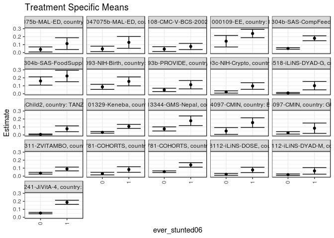

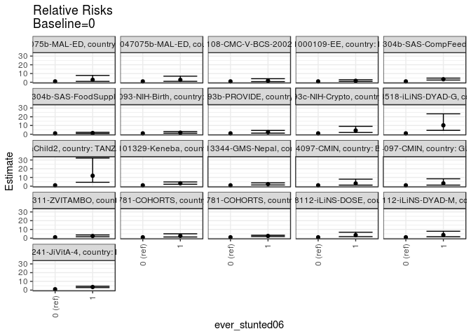

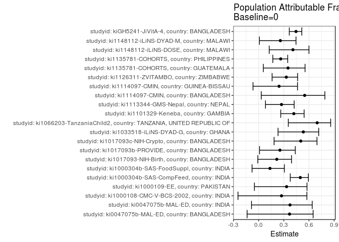

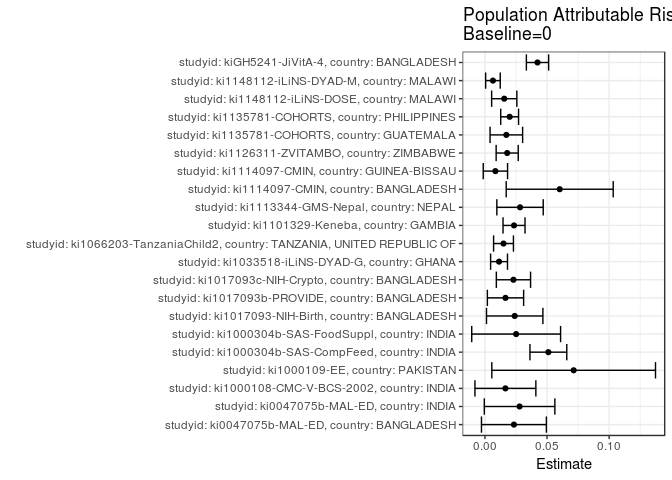

## Results Table

### Parameter: TSM

| studyid | country | intervention_level | baseline_level | estimate | ci_lower | ci_upper |
| --- | --- | --- | --- | --- | --- | --- |
| ki0047075b-MAL-ED | BANGLADESH | 0 | NA | 0.0400000 | 0.0085694 | 0.0714306 |
| ki0047075b-MAL-ED | BANGLADESH | 1 | NA | 0.1126761 | 0.0389602 | 0.1863919 |
| ki0047075b-MAL-ED | INDIA | 0 | NA | 0.0466667 | 0.0128382 | 0.0804952 |
| ki0047075b-MAL-ED | INDIA | 1 | NA | 0.1282051 | 0.0538493 | 0.2025610 |
| ki1000108-CMC-V-BCS-2002 | INDIA | 0 | NA | 0.0439560 | 0.0141326 | 0.0737795 |
| ki1000108-CMC-V-BCS-2002 | INDIA | 1 | NA | 0.0769231 | 0.0381565 | 0.1156896 |
| ki1000109-EE | PAKISTAN | 0 | NA | 0.1428571 | 0.0708582 | 0.2148561 |
| ki1000109-EE | PAKISTAN | 1 | NA | 0.2393822 | 0.1873409 | 0.2914236 |
| ki1000304b-SAS-CompFeed | INDIA | 0 | NA | 0.0517241 | 0.0418760 | 0.0615722 |
| ki1000304b-SAS-CompFeed | INDIA | 1 | NA | 0.1796407 | 0.1488413 | 0.2104401 |
| ki1000304b-SAS-FoodSuppl | INDIA | 0 | NA | 0.1606218 | 0.1087389 | 0.2125046 |
| ki1000304b-SAS-FoodSuppl | INDIA | 1 | NA | 0.2230769 | 0.1514022 | 0.2947517 |
| ki1017093-NIH-Birth | BANGLADESH | 0 | NA | 0.0866667 | 0.0547954 | 0.1185380 |
| ki1017093-NIH-Birth | BANGLADESH | 1 | NA | 0.1552795 | 0.0992753 | 0.2112837 |
| ki1017093b-PROVIDE | BANGLADESH | 0 | NA | 0.0486618 | 0.0278417 | 0.0694819 |
| ki1017093b-PROVIDE | BANGLADESH | 1 | NA | 0.1134752 | 0.0610756 | 0.1658748 |
| ki1017093c-NIH-Crypto | BANGLADESH | 0 | NA | 0.0227790 | 0.0088114 | 0.0367467 |
| ki1017093c-NIH-Crypto | BANGLADESH | 1 | NA | 0.0974359 | 0.0557804 | 0.1390914 |
| ki1033518-iLiNS-DYAD-G | GHANA | 0 | NA | 0.0099558 | 0.0034808 | 0.0164307 |
| ki1033518-iLiNS-DYAD-G | GHANA | 1 | NA | 0.1015625 | 0.0492068 | 0.1539182 |
| ki1066203-TanzaniaChild2 | TANZANIA, UNITED REPUBLIC OF | 0 | NA | 0.0064683 | 0.0008142 | 0.0121224 |
| ki1066203-TanzaniaChild2 | TANZANIA, UNITED REPUBLIC OF | 1 | NA | 0.0772947 | 0.0408956 | 0.1136938 |
| ki1101329-Keneba | GAMBIA | 0 | NA | 0.0324190 | 0.0224078 | 0.0424301 |
| ki1101329-Keneba | GAMBIA | 1 | NA | 0.1068841 | 0.0811023 | 0.1326658 |
| ki1113344-GMS-Nepal | NEPAL | 0 | NA | 0.0753769 | 0.0494170 | 0.1013368 |
| ki1113344-GMS-Nepal | NEPAL | 1 | NA | 0.1776316 | 0.1168160 | 0.2384471 |
| ki1114097-CMIN | BANGLADESH | 0 | NA | 0.0495050 | 0.0071109 | 0.0918990 |
| ki1114097-CMIN | BANGLADESH | 1 | NA | 0.1544118 | 0.0935539 | 0.2152696 |
| ki1114097-CMIN | GUINEA-BISSAU | 0 | NA | 0.0261905 | 0.0109016 | 0.0414793 |
| ki1114097-CMIN | GUINEA-BISSAU | 1 | NA | 0.0845070 | 0.0197428 | 0.1492713 |
| ki1126311-ZVITAMBO | ZIMBABWE | 0 | NA | 0.0363636 | 0.0252981 | 0.0474292 |
| ki1126311-ZVITAMBO | ZIMBABWE | 1 | NA | 0.0896057 | 0.0659005 | 0.1133110 |
| ki1135781-COHORTS | GUATEMALA | 0 | NA | 0.0319149 | 0.0160127 | 0.0478171 |
| ki1135781-COHORTS | GUATEMALA | 1 | NA | 0.0826446 | 0.0479293 | 0.1173600 |
| ki1135781-COHORTS | PHILIPPINES | 0 | NA | 0.0556430 | 0.0453472 | 0.0659389 |
| ki1135781-COHORTS | PHILIPPINES | 1 | NA | 0.1404110 | 0.1122288 | 0.1685932 |
| ki1148112-iLiNS-DOSE | MALAWI | 0 | NA | 0.0224719 | 0.0108269 | 0.0341169 |
| ki1148112-iLiNS-DOSE | MALAWI | 1 | NA | 0.0775510 | 0.0440406 | 0.1110615 |
| ki1148112-iLiNS-DYAD-M | MALAWI | 0 | NA | 0.0184544 | 0.0094913 | 0.0274176 |
| ki1148112-iLiNS-DYAD-M | MALAWI | 1 | NA | 0.0656934 | 0.0241875 | 0.1071993 |
| kiGH5241-JiVitA-4 | BANGLADESH | 0 | NA | 0.0527009 | 0.0441020 | 0.0612998 |
| kiGH5241-JiVitA-4 | BANGLADESH | 1 | NA | 0.1878613 | 0.1617817 | 0.2139408 |

### Parameter: E(Y)

| studyid | country | intervention_level | baseline_level | estimate | ci_lower | ci_upper |
| --- | --- | --- | --- | --- | --- | --- |
| ki0047075b-MAL-ED | BANGLADESH | NA | NA | 0.0633484 | 0.0311604 | 0.0955364 |
| ki0047075b-MAL-ED | INDIA | NA | NA | 0.0745614 | 0.0403897 | 0.1087331 |
| ki1000108-CMC-V-BCS-2002 | INDIA | NA | NA | 0.0604396 | 0.0359254 | 0.0849538 |
| ki1000109-EE | PAKISTAN | NA | NA | 0.2142857 | 0.1712366 | 0.2573348 |
| ki1000304b-SAS-CompFeed | INDIA | NA | NA | 0.1027888 | 0.0905676 | 0.1150101 |
| ki1000304b-SAS-FoodSuppl | INDIA | NA | NA | 0.1857585 | 0.1432798 | 0.2282372 |
| ki1017093-NIH-Birth | BANGLADESH | NA | NA | 0.1106291 | 0.0819645 | 0.1392936 |
| ki1017093b-PROVIDE | BANGLADESH | NA | NA | 0.0652174 | 0.0446012 | 0.0858336 |
| ki1017093c-NIH-Crypto | BANGLADESH | NA | NA | 0.0457413 | 0.0294659 | 0.0620168 |
| ki1033518-iLiNS-DYAD-G | GHANA | NA | NA | 0.0213178 | 0.0125010 | 0.0301346 |
| ki1066203-TanzaniaChild2 | TANZANIA, UNITED REPUBLIC OF | NA | NA | 0.0214286 | 0.0123577 | 0.0304995 |
| ki1101329-Keneba | GAMBIA | NA | NA | 0.0558405 | 0.0450949 | 0.0665861 |
| ki1113344-GMS-Nepal | NEPAL | NA | NA | 0.1036364 | 0.0781411 | 0.1291317 |
| ki1114097-CMIN | BANGLADESH | NA | NA | 0.1097046 | 0.0698323 | 0.1495770 |
| ki1114097-CMIN | GUINEA-BISSAU | NA | NA | 0.0346232 | 0.0184356 | 0.0508108 |
| ki1126311-ZVITAMBO | ZIMBABWE | NA | NA | 0.0542823 | 0.0433730 | 0.0651916 |
| ki1135781-COHORTS | GUATEMALA | NA | NA | 0.0491573 | 0.0332659 | 0.0650487 |
| ki1135781-COHORTS | PHILIPPINES | NA | NA | 0.0755323 | 0.0651490 | 0.0859156 |
| ki1148112-iLiNS-DOSE | MALAWI | NA | NA | 0.0380184 | 0.0252887 | 0.0507482 |
| ki1148112-iLiNS-DYAD-M | MALAWI | NA | NA | 0.0249004 | 0.0152571 | 0.0345437 |
| kiGH5241-JiVitA-4 | BANGLADESH | NA | NA | 0.0950226 | 0.0844790 | 0.1055662 |

### Parameter: RR

| studyid | country | intervention_level | baseline_level | estimate | ci_lower | ci_upper |
| --- | --- | --- | --- | --- | --- | --- |
| ki0047075b-MAL-ED | BANGLADESH | 0 | 0 | 1.000000 | 1.0000000 | 1.000000 |
| ki0047075b-MAL-ED | BANGLADESH | 1 | 0 | 2.816901 | 1.0132564 | 7.831121 |
| ki0047075b-MAL-ED | INDIA | 0 | 0 | 1.000000 | 1.0000000 | 1.000000 |
| ki0047075b-MAL-ED | INDIA | 1 | 0 | 2.747253 | 1.0857212 | 6.951506 |
| ki1000108-CMC-V-BCS-2002 | INDIA | 0 | 0 | 1.000000 | 1.0000000 | 1.000000 |
| ki1000108-CMC-V-BCS-2002 | INDIA | 1 | 0 | 1.750000 | 0.7515938 | 4.074674 |
| ki1000109-EE | PAKISTAN | 0 | 0 | 1.000000 | 1.0000000 | 1.000000 |
| ki1000109-EE | PAKISTAN | 1 | 0 | 1.675676 | 0.9678627 | 2.901123 |
| ki1000304b-SAS-CompFeed | INDIA | 0 | 0 | 1.000000 | 1.0000000 | 1.000000 |
| ki1000304b-SAS-CompFeed | INDIA | 1 | 0 | 3.473054 | 2.5222482 | 4.782282 |
| ki1000304b-SAS-FoodSuppl | INDIA | 0 | 0 | 1.000000 | 1.0000000 | 1.000000 |
| ki1000304b-SAS-FoodSuppl | INDIA | 1 | 0 | 1.388834 | 0.8806144 | 2.190356 |
| ki1017093-NIH-Birth | BANGLADESH | 0 | 0 | 1.000000 | 1.0000000 | 1.000000 |
| ki1017093-NIH-Birth | BANGLADESH | 1 | 0 | 1.791687 | 1.0704377 | 2.998905 |
| ki1017093b-PROVIDE | BANGLADESH | 0 | 0 | 1.000000 | 1.0000000 | 1.000000 |
| ki1017093b-PROVIDE | BANGLADESH | 1 | 0 | 2.331915 | 1.2425594 | 4.376312 |
| ki1017093c-NIH-Crypto | BANGLADESH | 0 | 0 | 1.000000 | 1.0000000 | 1.000000 |
| ki1017093c-NIH-Crypto | BANGLADESH | 1 | 0 | 4.277436 | 2.0255716 | 9.032738 |
| ki1033518-iLiNS-DYAD-G | GHANA | 0 | 0 | 1.000000 | 1.0000000 | 1.000000 |
| ki1033518-iLiNS-DYAD-G | GHANA | 1 | 0 | 10.201389 | 4.4487581 | 23.392671 |
| ki1066203-TanzaniaChild2 | TANZANIA, UNITED REPUBLIC OF | 0 | 0 | 1.000000 | 1.0000000 | 1.000000 |
| ki1066203-TanzaniaChild2 | TANZANIA, UNITED REPUBLIC OF | 1 | 0 | 11.949758 | 4.4273686 | 32.253178 |
| ki1101329-Keneba | GAMBIA | 0 | 0 | 1.000000 | 1.0000000 | 1.000000 |
| ki1101329-Keneba | GAMBIA | 1 | 0 | 3.296962 | 2.2281133 | 4.878549 |
| ki1113344-GMS-Nepal | NEPAL | 0 | 0 | 1.000000 | 1.0000000 | 1.000000 |
| ki1113344-GMS-Nepal | NEPAL | 1 | 0 | 2.356579 | 1.4500364 | 3.829879 |
| ki1114097-CMIN | BANGLADESH | 0 | 0 | 1.000000 | 1.0000000 | 1.000000 |
| ki1114097-CMIN | BANGLADESH | 1 | 0 | 3.119118 | 1.2151260 | 8.006491 |
| ki1114097-CMIN | GUINEA-BISSAU | 0 | 0 | 1.000000 | 1.0000000 | 1.000000 |
| ki1114097-CMIN | GUINEA-BISSAU | 1 | 0 | 3.226633 | 1.2312830 | 8.455536 |
| ki1126311-ZVITAMBO | ZIMBABWE | 0 | 0 | 1.000000 | 1.0000000 | 1.000000 |
| ki1126311-ZVITAMBO | ZIMBABWE | 1 | 0 | 2.464158 | 1.6464626 | 3.687951 |
| ki1135781-COHORTS | GUATEMALA | 0 | 0 | 1.000000 | 1.0000000 | 1.000000 |
| ki1135781-COHORTS | GUATEMALA | 1 | 0 | 2.589532 | 1.3495509 | 4.968819 |
| ki1135781-COHORTS | PHILIPPINES | 0 | 0 | 1.000000 | 1.0000000 | 1.000000 |
| ki1135781-COHORTS | PHILIPPINES | 1 | 0 | 2.523423 | 1.9205811 | 3.315489 |
| ki1148112-iLiNS-DOSE | MALAWI | 0 | 0 | 1.000000 | 1.0000000 | 1.000000 |
| ki1148112-iLiNS-DOSE | MALAWI | 1 | 0 | 3.451020 | 1.7575962 | 6.776040 |
| ki1148112-iLiNS-DYAD-M | MALAWI | 0 | 0 | 1.000000 | 1.0000000 | 1.000000 |
| ki1148112-iLiNS-DYAD-M | MALAWI | 1 | 0 | 3.559763 | 1.6044382 | 7.898036 |
| kiGH5241-JiVitA-4 | BANGLADESH | 0 | 0 | 1.000000 | 1.0000000 | 1.000000 |
| kiGH5241-JiVitA-4 | BANGLADESH | 1 | 0 | 3.564668 | 2.8799909 | 4.412116 |

### Parameter: PAR

| studyid | country | intervention_level | baseline_level | estimate | ci_lower | ci_upper |
| --- | --- | --- | --- | --- | --- | --- |
| ki0047075b-MAL-ED | BANGLADESH | 0 | NA | 0.0233484 | -0.0027845 | 0.0494814 |
| ki0047075b-MAL-ED | INDIA | 0 | NA | 0.0278947 | -0.0005011 | 0.0562906 |
| ki1000108-CMC-V-BCS-2002 | INDIA | 0 | NA | 0.0164835 | -0.0080307 | 0.0409977 |
| ki1000109-EE | PAKISTAN | 0 | NA | 0.0714286 | 0.0055387 | 0.1373184 |
| ki1000304b-SAS-CompFeed | INDIA | 0 | NA | 0.0510647 | 0.0362401 | 0.0658893 |
| ki1000304b-SAS-FoodSuppl | INDIA | 0 | NA | 0.0251368 | -0.0106321 | 0.0609056 |
| ki1017093-NIH-Birth | BANGLADESH | 0 | NA | 0.0239624 | 0.0012604 | 0.0466644 |
| ki1017093b-PROVIDE | BANGLADESH | 0 | NA | 0.0165556 | 0.0019610 | 0.0311502 |
| ki1017093c-NIH-Crypto | BANGLADESH | 0 | NA | 0.0229623 | 0.0091852 | 0.0367393 |
| ki1033518-iLiNS-DYAD-G | GHANA | 0 | NA | 0.0113621 | 0.0045642 | 0.0181599 |
| ki1066203-TanzaniaChild2 | TANZANIA, UNITED REPUBLIC OF | 0 | NA | 0.0149603 | 0.0069717 | 0.0229488 |
| ki1101329-Keneba | GAMBIA | 0 | NA | 0.0234215 | 0.0145733 | 0.0322697 |
| ki1113344-GMS-Nepal | NEPAL | 0 | NA | 0.0282595 | 0.0095890 | 0.0469299 |
| ki1114097-CMIN | BANGLADESH | 0 | NA | 0.0601997 | 0.0171274 | 0.1032720 |
| ki1114097-CMIN | GUINEA-BISSAU | 0 | NA | 0.0084327 | -0.0013596 | 0.0182251 |
| ki1126311-ZVITAMBO | ZIMBABWE | 0 | NA | 0.0179186 | 0.0090313 | 0.0268060 |
| ki1135781-COHORTS | GUATEMALA | 0 | NA | 0.0172424 | 0.0041444 | 0.0303404 |
| ki1135781-COHORTS | PHILIPPINES | 0 | NA | 0.0198893 | 0.0127093 | 0.0270693 |
| ki1148112-iLiNS-DOSE | MALAWI | 0 | NA | 0.0155465 | 0.0053980 | 0.0256950 |
| ki1148112-iLiNS-DYAD-M | MALAWI | 0 | NA | 0.0064460 | 0.0005655 | 0.0123264 |
| kiGH5241-JiVitA-4 | BANGLADESH | 0 | NA | 0.0423217 | 0.0333628 | 0.0512806 |

### Parameter: PAF

| studyid | country | intervention_level | baseline_level | estimate | ci_lower | ci_upper |
| --- | --- | --- | --- | --- | --- | --- |
| ki0047075b-MAL-ED | BANGLADESH | 0 | NA | 0.3685714 | -0.1374285 | 0.6494707 |
| ki0047075b-MAL-ED | INDIA | 0 | NA | 0.3741176 | -0.0850804 | 0.6389865 |
| ki1000108-CMC-V-BCS-2002 | INDIA | 0 | NA | 0.2727273 | -0.2462215 | 0.5755765 |
| ki1000109-EE | PAKISTAN | 0 | NA | 0.3333333 | -0.0499580 | 0.5767027 |
| ki1000304b-SAS-CompFeed | INDIA | 0 | NA | 0.4967923 | 0.3773099 | 0.5933483 |
| ki1000304b-SAS-FoodSuppl | INDIA | 0 | NA | 0.1353195 | -0.0784734 | 0.3067308 |
| ki1017093-NIH-Birth | BANGLADESH | 0 | NA | 0.2166013 | -0.0098714 | 0.3922855 |
| ki1017093b-PROVIDE | BANGLADESH | 0 | NA | 0.2538524 | 0.0106589 | 0.4372656 |
| ki1017093c-NIH-Crypto | BANGLADESH | 0 | NA | 0.5020030 | 0.1844692 | 0.6959023 |
| ki1033518-iLiNS-DYAD-G | GHANA | 0 | NA | 0.5329847 | 0.2315926 | 0.7161619 |
| ki1066203-TanzaniaChild2 | TANZANIA, UNITED REPUBLIC OF | 0 | NA | 0.6981457 | 0.3537738 | 0.8590029 |
| ki1101329-Keneba | GAMBIA | 0 | NA | 0.4194361 | 0.2636685 | 0.5422518 |
| ki1113344-GMS-Nepal | NEPAL | 0 | NA | 0.2726792 | 0.0818677 | 0.4238352 |
| ki1114097-CMIN | BANGLADESH | 0 | NA | 0.5487433 | 0.0314149 | 0.7897628 |
| ki1114097-CMIN | GUINEA-BISSAU | 0 | NA | 0.2435574 | -0.0670633 | 0.4637568 |
| ki1126311-ZVITAMBO | ZIMBABWE | 0 | NA | 0.3301010 | 0.1609692 | 0.4651392 |
| ki1135781-COHORTS | GUATEMALA | 0 | NA | 0.3507599 | 0.0561805 | 0.5533969 |
| ki1135781-COHORTS | PHILIPPINES | 0 | NA | 0.2633216 | 0.1689595 | 0.3469692 |
| ki1148112-iLiNS-DOSE | MALAWI | 0 | NA | 0.4089207 | 0.1262063 | 0.6001633 |
| ki1148112-iLiNS-DYAD-M | MALAWI | 0 | NA | 0.2588697 | 0.0098220 | 0.4452774 |
| kiGH5241-JiVitA-4 | BANGLADESH | 0 | NA | 0.4453855 | 0.3657596 | 0.5150148 |